# GDP Analysis for Switzerland

# Box-Jenkins (1976) Modeling Approach

In this analysis, I look into Swiss GDP by following wideliy accepted [Box-Jenkins (1976)](https://www.amazon.com/Time-Series-Analysis-Forecasting-Control/dp/0130607746) methododolgy to analyse time series. This approach involves the following steps:

1. Model Identification/Specification
2. Model Estimation
3. Model Validation
4. Forecasting

This analysis is done for the didactic reasons to show how this procedure works in practice. Strictly speaking, the model identification stage must include: visual inspection, statistical tests for stationarity, examination of Autocorrelation Function (ACF) and Partial Autocorrelation Function (PACF) plots and information criteria to identify the orders of autoregressive and moving average components. Here, I skip certain steps: I first plot raw and transformed data, from that I decide which filtered time series enters the subsequent steps. Importantly, I proceed to utilising different model specification tools, i.e., sample ACF and sample PACF plots and information, criteria assuming stationarity. Using information obtained at first step, I estimate AR(1) model with intercept using Least Squares Method. Then I proceed with Model Diagnostics, where I test if the model is good fit for the data, which is followed by Model Modifications. These step repeat as many times as necessary. The purpose of this "looping" procedure is to come up with most optimal model that captures as much information about the process as possible, i.e., model with residuals that most resemble white noise process. Moreover, I provide Python code for each step with output and my comment to them.

# Cleaning Up the Console and Setting the Working Directory

To clean up all previously created variables and clean up console use the following:

```python
from IPython import get_ipython
```

```python
get_ipython().magic('reset -sf')
get_ipython().magic('clear')
```

To change the working directory, use the following:

```python
import os
```

```python
path = "enter your path here with slash"
os.chdir(path)
```

# Importing Necessary Packages and Setting Style of Plots

The following packages are used in this analysis.

```python
from pandas import read_csv
from scipy import signal, linalg
import statsmodels.regression.linear_model as rg
import matplotlib.pyplot as plt
import statsmodels.stats.diagnostic as dg
from scipy import stats
import pandas as pd, matplotlib.pyplot as plt, numpy as np, \
    statsmodels.graphics.tsaplots as tsp, statsmodels.tsa as tsm, \
    statsmodels.api as sm
import collections
from numpy.linalg import inv
from scipy.optimize import fmin_bfgs
import statsmodels.tsa as tsm
from statsmodels.tsa.stattools import adfuller
```

Use the following command to set the style of plots to "seaborn".

```python
plt.style.use("seaborn-v0_8")
```

# Self-written functions

In this analysis I used the following self-written functions:

Function for computing sample autocorrelation and partial sample autocorrelation:

```python
def scf(y_t, h):
    T=len(y_t)
    y_bar=np.average(y_t)
    dif=y_t-y_bar
    gamma_not=np.sum(dif**2)/T
    gamma_h=np.zeros(h+1)
    gamma_h[0]=gamma_not
    for i in range(1,h+1):
        gamma_h[i]=np.sum(dif[i:]*dif[:-i])/(T-i)
    rho_h=gamma_h/gamma_not
    phi_hh=np.zeros(h)
    phi_hh[0]=rho_h[1]
    for i in range(2,h+1):
        D= linalg.toeplitz(rho_h[:i])
        D_phi = linalg.toeplitz(rho_h[:i])
        D_phi[:,-1]=rho_h[1:i+1]
        phi_hh[i-1]=np.linalg.det(D_phi)/np.linalg.det(D)
    rho_h=rho_h[1:]
    return rho_h, phi_hh
```

Function that estimates AR(p) process using LS method

```python
def est_arp(data, p, c, d): #p - order of AR process, d- dummy
    T = len(data) - p
    if (c == 1):
       X = np.zeros(shape=(T, p+1))
       X[:,0] = np.array(np.ones(T))
       for ii in range(1, p+1):
           X[:,ii] = data[p-ii:-ii]
    else:
        X = np.zeros(shape=(T, p))
        for ii in range(1, p+1):
            X[:,ii-1] = data[p-ii:-ii]
    if (d == 1):
        X=np.column_stack((X, dummy))
    res_arp = sm.OLS(data[p:], X).fit()
    alpha_est = res_arp.params
    y_hat = res_arp.fittedvalues
    res = res_arp.resid
    sig_est = res_arp.cov_params()
    return alpha_est, sig_est, res, y_hat, res_arp
```

Fuction that calculates three information criteria: [Akaike Information Criterion](https://link.springer.com/chapter/10.1007/978-1-4612-1694-0_16), [Hannan-Quinn Information Criterion](https://www.jstor.org/stable/2985032), [Schwarz or Bayesian Information Criterion](https://www.jstor.org/stable/2958889).

```python
def info_crit(Y, maxLag):
    AIC = np.zeros(maxLag)
    HQ = np.zeros(maxLag)
    SC = np.zeros(maxLag)
    T = len(Y) - maxLag
    for p in range(1, maxLag + 1):
        y = Y[maxLag - p:]
        _, _, res, _, _ = est_arp(y, p, 1, 0)
        rss = np.mean(res**2)
        AIC[p-1] = np.log(rss) + (p + 1) * 2/T
        HQ[p-1] = np.log(rss) + (p + 1)* 2 * (np.log(np.log(T)))/T
        SC[p-1] = np.log(rss) + (p + 1)* np.log(T)/T

    val = np.array([AIC, SC, HQ])
    val1 = np.array([AIC, SC, HQ]).T
    infoC = np.amin(val, axis=1)
    lagOrder = np.argmin(val, axis=1)
    return infoC, lagOrder, val1
```

Function that de-means, standardizing function

```python
def stand(res):
    T=len(res)
    mean_res=np.mean(res)
    sigma_tilde=np.sum((res-mean_res)**2)/T
    stand_res=(res-mean_res)/np.sqrt(sigma_tilde)
    return stand_res
```

# Exporting data from the csv file

In this analysis, I look into data generating process of the quarterly seasonally adjusted real Swiss GDP which runs from the first quarter of 1980 or the last quarter of 2021. The data obtained from the publicly available [IMF databank](https://link.springer.com/chapter/10.1007/978-1-4612-1694-0_16). It can be also downloaded directly from my personal github page.

Extracting data from the csv file:

```python
csv_data = read_csv('swiss_gdp.csv')
```

To view columns' names and first 20 rows of data

```python
csv_data.head(20)
```

[output not shown]

# 1. Model Specification

## Visual Inspection

First we need to create variables that contain original data and its logarithms.

```python
#original series
pandemic_x = np.array(csv_data.SWISSGDP)
pandemic_date = pd.to_datetime(csv_data.DATE)

#the logarithm of the series
ln_pandemic_x=np.log(pandemic_x)
```

Plotting the series.

```python
#plotitng Figure_1
figure_1, (ax1, ax2) = plt.subplots(nrows=2, ncols=1, constrained_layout=True)

ax1.plot(pandemic_date, pandemic_x, linestyle='--')
ax1.set_title('The quaterly seasonally adjusted real Swiss GDP, m')
ax1.set_xlabel('Years')

ax2.plot(pandemic_date, ln_pandemic_x)
ax2.set_title('The logarithm of the quaterly seasonally adjusted real Swiss GDP')
ax2.set_xlabel('Years')

plt.tight_layout()
plt.show()

#saving picture
figure_1.savefig('Figure_1.jpg')
```

The data are the quarterly seasonally adjusted real Swiss GDP which runs from the first quarter of 1980 or the last quarter of 2021. First of all, we can see at the picture below that the graphs of the raw data and log-transformation (natural) of the data look more or less the same because logarithm is a monotonic function. This transformation often done in order to stabilize the variance. However, they do have different scale of the y axis. It is more convenient to work with the latter. From the plot of the natural logarithms we observe very pronounced upward trend (even though we can see certain “drops” during the major economic crises, e.g. great financial crisis of 2008 or 2020 corona pandemic).

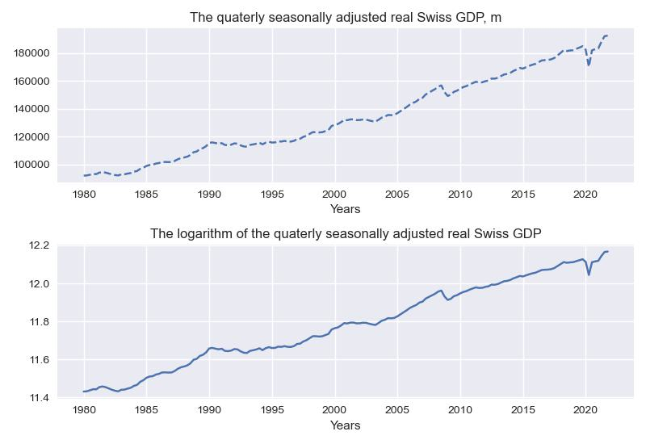

Apart from the log transformation, other time series transformation technics can be very informative. In this analysis, I look into the annualized quarter-over-quarter growth rates and annual growth rate (both in percentage). I first give definitions of both filters, then a short analyses of the results.

The annualized growth rate in $\%$ is $400 × ∆ y_{t}$, where $∆ y_{t} ≔ y_{t} − y_{t−1}$.

The annual growth rate in $\%$ is $100 × ∆_{4} y_{t}$, where $∆_{s} y_{t} ≔ y_{t} − y_{t−s}$.

Applying transformations to the data:

```python
#the annualized quarter-over-quarter growth rates of the series in %
pandemic_y_t=400*(ln_pandemic_x[1:]-ln_pandemic_x[:-1])

#the year-over-year (annual) growth rates of the series in %.
an_gr_rate=100*(ln_pandemic_x[4:] - ln_pandemic_x[:-4])
```

Plotting filtered time series:

```python
 #plotting Figure_2
figure_2, (ax3, ax4) = plt.subplots(nrows=2, ncols=1, constrained_layout=True)

ax3.plot(pandemic_date[1:],pandemic_y_t)
ax3.set_title('The annualized quarter-over-quarter growth rates in % of the seasonally adjusted real Swiss GDP', wrap=True)
ax3.set_xlabel('Years')

ax4.plot(pandemic_date[4:], an_gr_rate)
ax4.set_title('The year-over-year (annual) growth rates in % of the seasonally adjusted real Swiss GDP')
ax4.set_xlabel('Years')

plt.tight_layout()
plt.show()

#saving Figure_2
figure_2.savefig('Figure_2.jpg')
```

In both cases, both filters "produce" time series that no longer exhibit trending behavior, instead as can be seen below the series have cyclical variation about some constant mean value (the reason might be that the original quarterly series has stochastic trend, i.e. it is difference stationary). Moreover, the annual growth rates in % moves up and down but not as frequent as the annualized quarter-over-quarter growth rates in %. We could say that annual growth rate has more persistence, i.e. it might be that it is much stronger serially correlated than the annualized quarter-over-quarter growth rates.

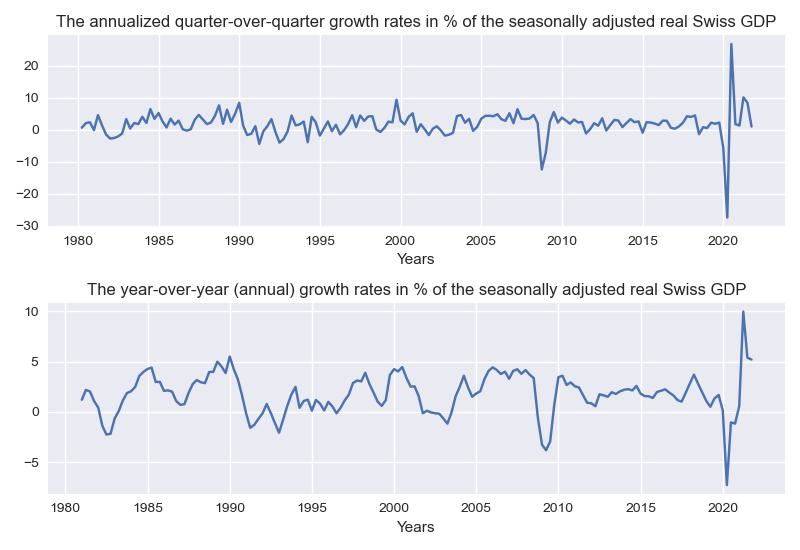

## Choosing Filtered Time Series for Analysis

Since this analysis is done mostly for the didactic reasons, I take into consideration only pre-pandemic data from 1980Q1 to 2019Q4 for the following investigations. The variable in question is the annualized quarter-over-quarter growth rates of the series in %.

Creating variables containing new time period.

```python
#using pre-pandemic data from 1980Q1 to 2019Q4 for the following analysis:
x=pandemic_x[:-8]
ln_x=np.log(x)

#the annualized quarter-over-quarter growth rates of the series in %
y_t=400*(ln_x[1:]-ln_x[:-1])
date=pandemic_date[1:-8]
```

## Examining Sample ACF and Sample PACF Plots

For the sake of clarity, I provide several formulas that define entities used in this analysis.

Sample mean: $\bar {y} = \frac{1}{T} \sum_{t=1}^{T} y_{t}$

Sample variance: $\hat{γ}_{0} = \frac{1}{T} \sum_{t=1}^{T} (y_{t}-\bar {y})^{2}$

Sample autocovariance function at lag $h$: $\hat{γ}_{h} = \frac{1}{(T-h)} \sum_{t=h+1}^{T} (y_{t}-\bar {y})(y_{t-h}-\bar {y})$ for $h=0,1, …$

The **Sample Autocorrelation Function (SACF)** at lag $h$ with with $|\hat{ρ}_{h}|≤1$ is computed as follows:

$$\hat{ρ}_{h} = \frac{\hat{γ}_{h}}{\hat{γ}_{0}},   h=0,1, …$$

The **Population Partial Autocorrelation Function (PACF)** at lag $h$ can be defined as:

$$φ_{hh} ≔ \text{Corr}(y_{t}, y_{t-h} ∣ y_{t − 1}, … , y_{t − h + 1})$$

Its sample conterpart is computed using the Yule-Walter equations. For the exact description of the procedure see Section 2.3 in [Wen (2006)](https://civil.colorado.edu/~balajir/CVEN6833/lectures/wwts-book.pdf).

Correlograms are histograms, where calculated sample autocorrelations and partial sample autocorrelations are plotted against $h$. It is a very useful tool since they provide important information about sign and the size of the dependencies over time. Assuming weak stationarity every type of data generating process (Moving Average (MA) Processes, Autoregressive (AR) Processes, Autoregressive Moving Average (ARMA) Processes) have theirown unique "shapes" of correlograms.

Let us start with initial assumption that the data have been generated by a White Noise (WN) process. White Noise process is a covariance (weakly) stationary process with zero mean, time invariant variance, and zero autocorrelation. It can be shown that the null hypothesis of zero autocorrelation is rejected if $∣ \hat{ρ}_{h} ∣ > (1.96/\sqrt{T})$ where $T$ is number of observations in the time series see, [Time Series, Analysis, Section 7, Hamilton (1994)](https://www.amazon.com/Time-Series-Analysis-James-Hamilton/dp/0691042896); hereafter, unless stated otherwise, the confidence level is 95% see.

In practice, $\widehat{ρ}_{h}$ is compared to $(±2/\sqrt{T})$ bound. Only if we have spikes outside this bound in the correlogram, we judge that autocorellation being significantly different from zero.

Calculating SACF and SPACF and plotting them against $h$:

```python
# computing SACFs for the lags up to 12 for y_t
h=12
T=len(y_t)
#use self-written scf function to calculate sacf and spacf
sacf, _ = scf(y_t, h)
_, spacf= scf(y_t, h)

#Plot SACFs and SPACFs for yt together with +-2/sqrtT bounds
lnspc = np.linspace(1, h, h)

figure_3, (ax5, ax6) = plt.subplots(nrows=1, ncols=2, constrained_layout=True)

ax5.bar(lnspc, sacf, alpha=1)
ax5.set_title('SACF')
ax5.set_xlabel('$h$')

ax5.hlines(2/np.sqrt(T), 0.009, lnspc[-1], linestyles='dashed', color='r')
ax5.hlines(-2/np.sqrt(T), 0.009, lnspc[-1], linestyles='dashed', color='r')
ax5.hlines(0, 0.009, lnspc[-1], linestyles='dashed', color='black')
ax5.set_ylim(-0.6,0.6)

ax6.bar(lnspc, spacf, alpha=1)
ax6.set_title('SPACF')
ax6.set_xlabel('$h$')

ax6.hlines(2/np.sqrt(T), 0.009, lnspc[-1]+0.5, linestyles='dashed', color='r')
ax6.hlines(-2/np.sqrt(T), 0.009, lnspc[-1]+0.5, linestyles='dashed', color='r')
ax6.hlines(0, 0.009, lnspc[-1], linestyles='dashed', color='black')
ax6.set_ylim(-0.60,0.60)

plt.tight_layout()
plt.show()

#saving Figure_3
figure_3.savefig('Figure_3.jpg')
```

We can see the histogram representation of the results of the sample autocorrelation and partial autocorrelation function below. Red dotted line represents $(±2/\sqrt{T})$ bound. From the first glimpse it can be said that both SACF and SPACF are statistically different from zero at lag 1. Although, there are no very obvious patterns (compare to the “theoretical” patterns of simulated series), however, seemingly slower decay of SACF and clearer cut-off point of SPACF (at lag 1) are observed. From that we can conclude that we are dealing with AR(1) model with not very big autoregressive parameter, but to be more certain diagnostic testing is needed.

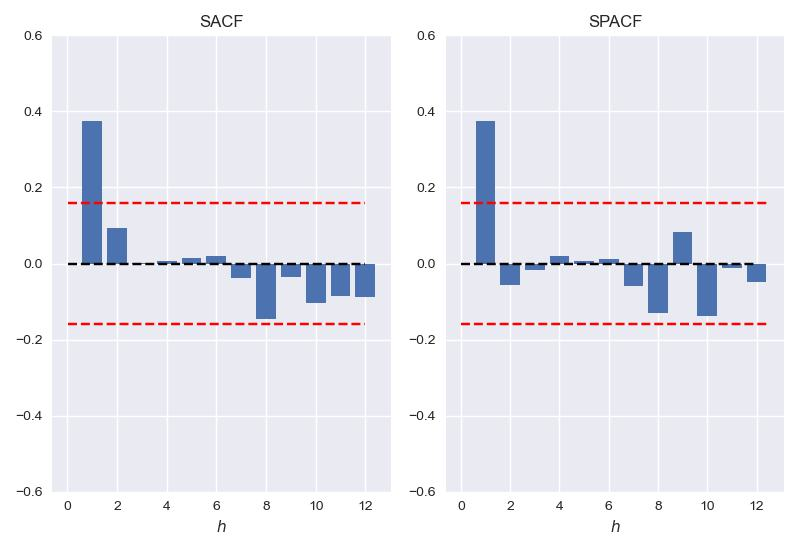

## Utilising Information Criteria

Another useful tool for model specification is information criteria; here I used AIC, HQ, and SC.

```python
#apply information criteria to select a pure AR model for y_t (use models with an intercept,
#pmax = 8).
pmax = 8
_, lag_order,_=info_crit(y_t, 8)
criteria, _ ,_=info_crit(y_t, 8)
_, _, cr_results =info_crit(y_t, 8)
#print the results
print(lag_order, criteria)
dash = '-' * 50
print(dash)
print ('{:^55}'.format('Order Selection Criteria'))
print(dash)
print('{:<12s} {:^12s} {:^12s} {:^12s}'.format('lag', 'AIC',
      'HQ', 'SC'))
print(dash)
print('{:<12s} {:^8.4f} {:^16.4f} {:^8.4f}'.format('1.0', cr_results[0,0],
      cr_results[0,1], cr_results[0,2]))
print('{:<12s} {:^8.4f} {:^16.4f} {:^8.4f}'.format('2.0', cr_results[1,0],
      cr_results[1,1], cr_results[2,2]))
print('{:<12s} {:^8.4f} {:^16.4f} {:^8.4f}'.format('3.0', cr_results[2,0],
      cr_results[2,1], cr_results[2,2]))
print('{:<12s} {:^8.4f} {:^16.4f} {:^8.4f}'.format('4.0', cr_results[3,0],
      cr_results[3,1], cr_results[3,2]))
print('{:<12s} {:^8.4f} {:^16.4f} {:^8.4f}'.format('5.0', cr_results[4,0],
      cr_results[4,1], cr_results[4,2]))
print('{:<12s} {:^8.4f} {:^16.4f} {:^8.4f}'.format('6.0', cr_results[5,0],
      cr_results[5,1], cr_results[5,2]))
print('{:<12s} {:^8.4f} {:^16.4f} {:^8.4f}'.format('7.0', cr_results[6,0],
      cr_results[6,1], cr_results[6,2]))
print('{:<12s} {:^8.4f} {:^16.4f} {:^8.4f}'.format('8.0', cr_results[7,0],
      cr_results[7,1], cr_results[7,2]))
```

```
--------------------------------------------------
               Order Selection Criteria
--------------------------------------------------
lag              AIC           HQ           SC
--------------------------------------------------
1.0           1.8630       1.9030       1.8793
2.0           1.8735       1.9335       1.9190
3.0           1.8865       1.9664       1.9190
4.0           1.8993       1.9992       1.9399
5.0           1.9125       2.0324       1.9612
6.0           1.9257       2.0656       1.9825
7.0           1.9354       2.0952       2.0003
8.0           1.9327       2.1125       2.0057
```

In this analysis I calculated criteria values for eight lags. According to all three information criteria, the suggested lag order for the autoregressive model is 1.

# 2. Model Estimation

## Estimating AR(1) Model Using LS

So far both explorative tools of descriptive methods for model specification, correlograms and results from information criteria, indicate that assuming weak stationarity we might be dealing with AR(1) model. Let us fit AR(1) with intercept model to data and analyse it.

Consider the following autoregressive model of order 1 with intercept, AR(1):

$$y_{t} = c + α_{1} y_{t − 1} + ε_{t}   \text{with}   ε_{t} ∼ WN$$

I estimated this model using least-squares method. For the proof of the consistency of estimators and normality of asymptotic distributions together with assumptions needed for these results see [Time Series, Analysis, Section 8.2, Hamilton (1994)](https://www.amazon.com/Time-Series-Analysis-James-Hamilton/dp/0691042896). Usual statistical methods can be used here. If we look at t-test results both estimated parameters are statistically significant.

```python
# Estimate AR(1) for y_t, using the LS method and report the estimated parameters
#T for AR(1)
date1=date[1:]
ar1_param, sig_est, res, _, _ =est_arp(y_t, 1, 1, 0)
asym_se=np.array([np.sqrt(sig_est[0,0]), np.sqrt(sig_est[1,1]) ])
t_score_ar1=np.array([ar1_param[0]/asym_se[0], ar1_param[1]/asym_se[1]])
dash = '-' * 65
print(dash)
print ('{:^55}'.format('AR(1) Parameter Estimates and Asymptotic SEs (LS method)'))
print(dash)
print('{:<12s} {:^12s} {:^12s} {:^12s} {:^12s}'.format('Coefficient', 'Point Estimate','Asymptotic SE', 't-score', 'p-value'))
print(dash)
print('{:<12s} {:^8.4f} {:^16.4f} {:^16.4f} {:^8.4f}'.format('c',  ar1_param[0],
                                                             asym_se[0], t_score_ar1[0], np.round(stats.t.sf(abs(t_score_ar1[0]), df=len(y_t)), 4)))
print('{:<12s} {:^8.4f} {:^16.4f} {:^16.4f} {:^8.4f}'.format('alpha_1',  ar1_param[1],
                                                             asym_se[1], t_score_ar1[1], np.round(stats.t.sf(abs(t_score_ar1[1]), df=len(y_t)), 4)))
#here sigma hat squared is estimated using formula:
#sigma_hat^2=(1/(T-p-1))*sum(epsilon_hat^2) which is different from the likelihood
#estimate of sigma^2, where denominator consists only of T.
```

```
-----------------------------------------------------------------
AR(1) Parameter Estimates and Asymptotic SEs (LS method)
-----------------------------------------------------------------
Coefficient  Point Estimate Asymptotic SE   t-score      p-value
-----------------------------------------------------------------
c             1.1074       0.2386           4.6407       0.0000
alpha_1       0.3724       0.0743           5.0150       0.0000
```

If we look at the estimates, all of them are statistically significant. However, at this stage, it is too early to draw conclusions if this model is suitalbe for this time series.

# 3. Model Validation

At this stage, we need to check if the fitted model is adequate and captures all the dependencies in the data. For that we analyse its residuals: e.g., if residuals of the model are normally distributed, whether they are similar to realizations of a white noise process, i.e., they do not contain any remaining serial dependences. This part of the analysis is done according to the following framework:

- Descriptive Analysis of Residuals
- Residual Plots
- Plots of Residual ACFs and PACFs
- Diagnostic Test of Residuals

## Descriptive Analysis of Residuals

### Residual Plots

First, we try to detect possible model defects using plots of standardized residuals. Why standardized residuals? If the residuals are normally distributed, their standardized version should behave as standard normal quantity, i.e., 95% of them should be within a ±2 band around zero. That is why, we plot standardized residuals and just count how many of them are outside of this bound, in other words, how many "hits" there are. If the number is greater than 5% of the sample size, this is a clear indication that 1. residuals are not normally distributed or 2. presence of other problems (outlier, inhomogenous variances, structural breaks).

```python
#obtain standardized residuals
stand_res=stand(res)
```

```python
#plot standardized residuals
designdate1='1980-01-01'
designdate2='2019-04-01'
figure_4, ax7 = plt.subplots(nrows=1, ncols=1, constrained_layout=True)

ax7.plot(date1, stand_res)
ax7.set_title('Standardized residuals')
ax7.set_xlabel('Years')
ax7.hlines(2, pd.to_datetime(designdate1), pd.to_datetime(designdate2), linestyles='dashed', color='r')
ax7.hlines(-2, pd.to_datetime(designdate1), pd.to_datetime(designdate2), linestyles='dashed', color='r')
ax7.set_ylim(-6,4)

plt.tight_layout()
plt.show()
#save figure_4
figure_4.savefig('Figure_4.jpg')
```

In our example, number of observations for residuals is 158 (5% out of it makes 7.9). It can be seen from the plot of standardized residuals that we have 7 "hits", which is almost 5% of all observations. It is a borderline case, that might be an indication that residuals are not normally distributed or there are other problems that can damage the ability of the model to produce accurate forecast. Let us proceed and see what further analysis shows.

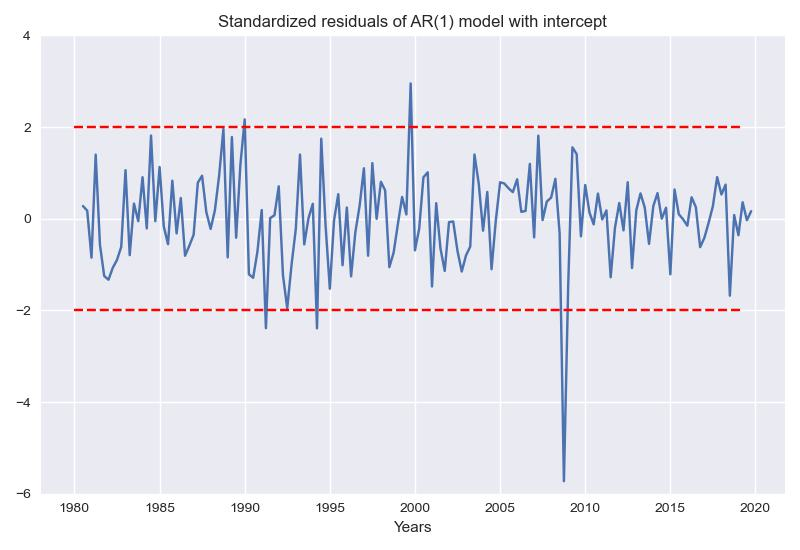

### Plots of Residual ACFs and PACFs

Calculate and plot residual ACFs and PACFs of AR(1) model with intercept:

```python
#calcule residual ACFs and PACFs
res_acf, _ = scf(res, 35)
_, res_spacf= scf(res, 35)

#plot residual ACF's and PACF's
lnspc_residual = np.linspace(1, 35, 35)

figure_5, (ax8, ax9) = plt.subplots(nrows=1, ncols=2, constrained_layout=True)

ax8.bar(lnspc_residual, res_acf, alpha=1)
ax8.set_title('Residual ACFs')
ax8.set_xlabel('$h$')
ax8.hlines(2/np.sqrt(len(res)), 0.009, lnspc_residual[-1]+1, linestyles='dashed', color='r')
ax8.hlines(-2/np.sqrt(len(res)), 0.009, lnspc_residual[-1]+1, linestyles='dashed', color='r')
ax8.set_ylim(-0.4, 0.4)

ax9.bar(lnspc_residual, res_spacf, alpha=1)
ax9.set_title('Residual PACFs')
ax9.set_xlabel('$h$')
ax9.hlines(2/np.sqrt(len(res)), 0.009, lnspc_residual[-1]+1, linestyles='dashed', color='r')
ax9.hlines(-2/np.sqrt(len(res)), 0.009, lnspc_residual[-1]+1, linestyles='dashed', color='r')
ax9.set_ylim(-0.4, 0.4)

plt.tight_layout()
plt.show()

#save figure_5
picture_5.savefig('Figure_5.jpg')
```

If we look at the plots of residual ACFs and PACFs, it can be seen that low lags do not hit the $(±2/\sqrt{T})$ band. Moreover, even though actual distribution of ACF and PACF based on estimated processes implies smaller than the $(±2/\sqrt{T})$ bands, as we can see the estimated low lag ACFs and PACFs might not be big enough to hit their true band. However, the considerably large ACF and PACF at larger lags might be an indication of remaining serial correlation in residuals or the not normally distributed residuals, as we stated earlier more precise (formal) diagnostic testing is needed.

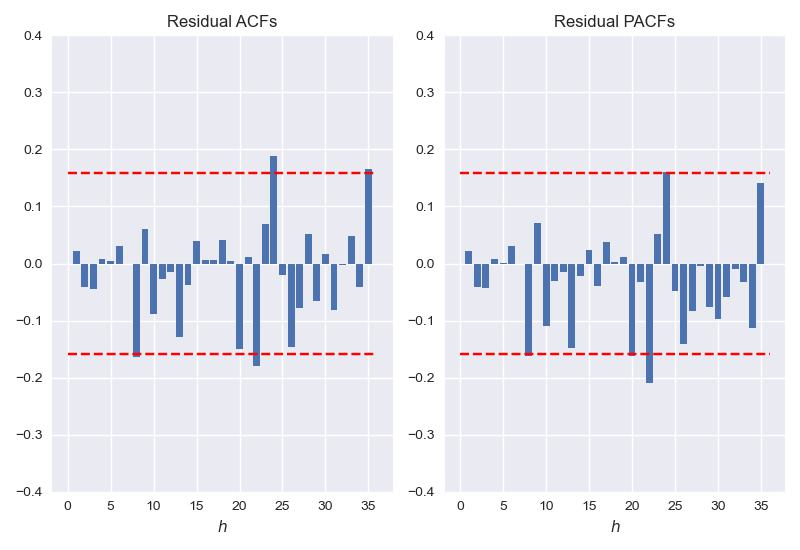

## Diagnostic Test of Residuals

### The Modified Portmanteau or Ljung-Box-Q-Test for Serial Autocorrelation

Here the idea is to test joint significance of first $h$ residual autocorrelations (in our example $h=35$), i.e. we are testing null hypothesis of no-serial correlation in all first 35 lags:

$$\begin{aligned}
H_{0}: &\; \rho_{\epsilon,1} = \ldots = \rho_{\epsilon,35} = 0   \text{vs.} \\
H_{1}: &\; \rho_{\epsilon,i} \ne 0   \text{for at least one} \; i = 1, \ldots, h
\end{aligned}$$

$$Q_{LB} = T(T+2) \sum_{\substack{j=1}}^h \frac{1}{(T-j)}\hat{ρ}_{ε,j}^{2}   ≈   χ^{2}(h-p-q) \tag{1}$$

In $(1)$, $\hat{ρ}_{ε,j}$ is residual autocorrelation at lag $j$. $(p+q)$ is number of parameters that show up in the ARMA model. In this analysis, I am running diagnostic tests for pure AR model, therefore $q=0$. We reject the null hypothesis if $Q_{LB} > χ^{2}(h-p-q)_{1-α}$([Ljung and Box, 1978](https://www.jstor.org/stable/2335207)).

Below you can find Python code, that tests serial autocorrelation at lags 20 and 35, since this test is not useful at lower lags.

```python
#%% Conducting diagnostic tests for remaining residual autocorrelation
#Ljung-Box
sm.stats.acorr_ljungbox(res, lags=[20], return_df=True)
sm.stats.acorr_ljungbox(res, lags=[35], return_df=True)
res_acf, _ = scf(res, 35)
_, res_spacf= scf(res, 35)
#SACF and SPACF at lag 35
res_acf_35, res_spacf_35=np.round(res_acf[34], 4), np.round(res_spacf[34], 4)
print(res_acf_35, res_spacf_35)
```

```
sm.stats.acorr_ljungbox(res, lags=[20], return_df=True)
Out[26]:
     lb_stat  lb_pvalue
20  12.98408   0.878066
sm.stats.acorr_ljungbox(res, lags=[35], return_df=True)
Out[27]:
      lb_stat  lb_pvalue
35  32.363867    0.59602
```

As this test take into consideration join significance, I presented resutls only for $h=35$. Test statistic $Q_{LB}$ is equal to 32.3639 and chi-square distributed with 34 degrees of freedom. The p-value is larger than 0.05, so there is not enough evidence to reject the null hypothesis of no serial correlation. In is very important to note here, that this test can not be used for lower lag orders. For that reason, I included Breusch-Godfrey LM-Test for autocorrelation as well.

### Breusch-Godfrey LM-Test for Residual Autocorrelation

To implement this test we first need to estimate the auxiliary model that regress the estimated residuals from the time series model on the set of the regressors that had been originally included the model and, in addition, lagged estimated residuals. Therefore, if I want to check autocorrelation up to and including lag $h=4$, I need to run the following auxiliary regression by standard LS:

$$\hat{ε}_{t} = c + α_{1}y_{t-1} + β_{1} \hat{ε}_{t-1} + β_{2} \hat{ε}_{t-2} + β_{3} \hat{ε}_{t-3} + β_{4} \hat{ε}_{t-4} + e_{t}$$

We test the null hypothesis of no autocorrelation:

$$\begin{aligned}
H_{0}: &\; β_{1} = \ldots = β_{4} = 0   \text{vs.} \\
H_{1}: &\; β_{1} ≠0   \text{or} \ldots \text{or}   β_{4} ≠0
\end{aligned}$$

The test statistic $LM_{h}$ is simply the number of observations $T$ multiplied by standard unadjusted $R^{2}$ from that auxiliary regression ([Breusch, 1978](https://onlinelibrary.wiley.com/doi/10.1111/j.1467-8454.1978.tb00635.x) and [Godfrey, 1978](https://www.jstor.org/stable/1913829)):

$$LM_{h} = TR^{2}$$

We reject the null hypothesis if $LM_{h} > χ^{2}(h)_{1-α}$, in this example, again $h=4$

```python
#Breusch-Godfrey LM-Test for Residual Autocorrelation
#estimating auxiliary regression
dependent=res
regress1= y_t[:-1]
mean_of_wn=np.zeros(4)
res1=res[:-1]
res1=np.append (mean_of_wn[0], res1)
res2=res[:-2]
res2=np.append(mean_of_wn[0:2], res2)
res3=res[:-3]
res3=np.append(mean_of_wn[0:3], res3)
res4=res[:-4]
res4=np.append(mean_of_wn[0:5], res4)
regressors=np.vstack((regress1, res1, res2, res3,res4)).T
regressors = sm.add_constant(regressors)
model = rg.OLS(dependent, regressors).fit()
rsq=model.rsquared
T=158
p=1
h=4
#calculating lm_h statistic
lm_h=rsq*T
#Printing lm_h statistic and p-value
print('Breusch-Godfrey LM-Test for Residual Autocorrelation')
print(' ')
print('Breusch-Godfrey LMh-Test statistic at lag=4:', np.round(lm_h, 6))
print('Breusch-Godfrey LM-Test p-value at lag=4:', np.round(1-stats.chi2.cdf(x=lm_h, df=h), 6))
```

```
Breusch-Godfrey LM-Test for Residual Autocorrelation

Breusch-Godfrey LMh-Test statistic at lag=4: 0.652873
Breusch-Godfrey LM-Test p-value at lag=4: 0.957011
```

Here test statistic is 0.652873 and p-value is equal to 0.9570 (much larger than 0.05), so there is not enough evidence to reject the null hypothesis of no autocorrelation.

### Breusch-Godfrey LM test / F version for Serial Autocorrelation

*F* version of the Breusch-Godfrey LM test has better properties in small samples, see [Chapter 11 Stock and Watson, 2020](https://www.amazon.com/Introduction-Econometrics-James-H-Stock/dp/0134461991). Here the test statistic is calculated using the same auxiliary model:

$$FLM_{h} = \frac{R^{2}}{1-R^{2}} × \frac{T-p-h-1}{h} ≈   F(h,   T-p-h-1) \tag{2}$$

Computing $FLM_{h}$ statistic using self-written function that utilises formula (2) for residual serial autocorrelation at lag 4.

```python
#calculating flm_h statistic and associated p-value
num=(T-p-h-1)
flm_h=(rsq*num)/((1-rsq)*h)
#Printing flm_h statistic and p-value
print('Breusch-Godfrey LM-Test for Residual Autocorrelation')
print(' ')
print('Breusch-Godfrey FLM-Test statistic at lag=4:', np.round(flm_h, 6))
print(f'Breusch-Godfrey FLM-Test p-value at lag=4:', np.round(1-stats.f.cdf(flm_h, h, num), 6))
```

```
Breusch-Godfrey LM-Test for Residual Autocorrelation

Breusch-Godfrey FLM-Test statistic at lag=4: 0.157672
Breusch-Godfrey FLM-Test p-value at lag=4: 0.959268
```

The test statistic is equal to 0.1577 and associated p-value is 0.9593, therefore the null hypothesis of no serial correlation again cannot be rejected.

For the sake of completeness the autocorrelation at lags 3, 5, 6, 7 were checked using in-build function, in all of the cases the null hypotheses cannot be rejected, see below

```python
#calculating LM statistic and p value using in-build package for lag=3,5,6,7
_, _, _, _, for_lm =est_arp(y_t, 1, 1, 0)
print('Breusch-Godfrey LM-Test for Residual Autocorrelation (in-build function)')
print(' ')
print('Breusch-Godfrey LM-Test statistic for lag=3:', np.round(dg.acorr_breusch_godfrey(for_lm, nlags=3)[0], 6))
print('Breusch-Godfrey LM-Test p-value for lag=3:', np.round(dg.acorr_breusch_godfrey(for_lm, nlags=3)[1], 6))
print('Breusch-Godfrey LM-Test statistic for lag=5:', np.round(dg.acorr_breusch_godfrey(for_lm, nlags=5)[0], 6))
print('Breusch-Godfrey LM-Test p-value for lag=5:', np.round(dg.acorr_breusch_godfrey(for_lm, nlags=5)[1], 6))
print('Breusch-Godfrey LM-Test statistic for lag=6:', np.round(dg.acorr_breusch_godfrey(for_lm, nlags=6)[0], 6))
print('Breusch-Godfrey LM-Test p-value for lag=6:', np.round(dg.acorr_breusch_godfrey(for_lm, nlags=6)[1], 6))
print('Breusch-Godfrey LM-Test statistic for lag=7:', np.round(dg.acorr_breusch_godfrey(for_lm, nlags=7)[0], 6))
print('Breusch-Godfrey LM-Test p-value for lag=7:', np.round(dg.acorr_breusch_godfrey(for_lm, nlags=7)[1], 6))
```

```
Breusch-Godfrey LM-Test for Residual Autocorrelation (in-build function)

 Breusch-Godfrey LM-Test statistic for lag=3: 0.605173
 Breusch-Godfrey LM-Test P-value for lag=3: 0.895247
 Breusch-Godfrey LM-Test statistic for lag=5: 0.664913
 Breusch-Godfrey LM-Test P-value for lag=5: 0.984839
 Breusch-Godfrey LM-Test statistic for lag=6: 0.838045
 Breusch-Godfrey LM-Test P-value for lag=6: 0.991015
 Breusch-Godfrey LM-Test statistic for lag=7: 0.838091
 Breusch-Godfrey LM-Test P-value for lag=7: 0.997036
```

### ARCH-LM Test for Autoregressive Conditional Heteroskedasticity

[Engle, 1982](https://www.jstor.org/stable/1912773) proposed to test for neglected autoregressive conditional heteroskedasticity (ARCH) by running:

$$\hat{ε}^{2}_{t} = β_{0} + β_{1} \hat{ε}^{2}_{t-1} + \ldots + β_{q} \hat{ε}^{2}_{t-q} + e_{t} \tag{3}$$

$$\begin{aligned}
H_{0}: &\; β_{1} = \ldots = β_{q} = 0   \text{vs.} \\
H_{1}: &\; β_{1} ≠0   \text{or} \ldots \text{or}   β_{q} ≠0
\end{aligned}$$

Again, the test statistic is equal to number of observations $T$ multiplied by the $R^2$ statistic of the autoregressive model (3). It is asymptotically chi-squared distributed with $q$ degrees of freedom.

$$ARCH_{LM}(q) = T × R^{2}$$

We reject the null hypothesis if $ARCH_{LM}(q) > χ^{2}(q)_{1-α}$, in this example, I tested for $q=8$

```python
#%%conduct diagnostic tests for ARCH effects
arch_lm = dg.het_arch(res, nlags=8)
print('ARCH-LM-test-stat in-build:', np.round(arch_lm[0],4))
print('ARCH-LM-pval in-build:', np.round(arch_lm[1], 4))
```

```
ARCH-LM-test-stat in-build: 0.8463
ARCH-LM-pval in-build: 0.999
```

We can see that p-value here is very large. So we do not have enough evidence to reject the null hypothesis of no ARCH effects.

### Jarque-Bera Test for Normality

```python
#Jarque-Bera test for non-normality
jarque_bera_test = stats.jarque_bera(stand_res)
print('Jarque-Bera test for non-normality (in-build function)')
print(' ')
print('Jarque-Bera Test statistic:', np.round(jarque_bera_test.statistic, 6))
print('Jarque-Bera Test P-value:', np.round(jarque_bera_test.pvalue, 6))
```

```
Jarque-Bera test for non-normality (in-build function)

 Jarque-Bera Test statistic: 261.213645
 Jarque-Bera Test P-value: 0.0
```

Here we test the null hypothesis of the standardized residuals being normally distributed, i.e. we test if residuals’ third moment is statistically different from zero and the forth moment is statistically different from 3 (standard normal distribution’s skewness and kurtosis). Interestingly, the p-value here is very small so we reject the null hypothesis of normality.

## The Overall Assessment of the Model Validation Stage

When I analyzed plots of standardized residuals and residual ACF and PACF, I stated that the problem can be 1. there is some remaining correlation in the residuals or 2. residuals might be non-normally distributed. None of the conducted test showed the evidence of presence of serial correlation. Therefore, the “problem” most probably is in non-normality of the residuals. But normality of the residuals is a bit of a strong restriction/assumption and taking into consideration that all information criteria indicated lag one as preferable, disregarding AR(1) all together would not be sensible decision and some other alterations might be implemented to buttress the model. Let us try to solve the "problem" of non-normality of the residuals by adding to the model at-hand a dummy variable, that will count for the 2008 Financial Crisis and test for normality of residuals again.

# Estimating AR(1) model with Intercept and Dummy Variable for 2008 Financial Crisis

```python
#create an impulse dummy to capture an unusually large residual in 2008Q4
dummy=np.zeros(len(date1))
dummy[113]=1
ar1_d, sig_dummy, res_dummy, _, for_lm2 =est_arp(y_t, 1, 1, 1)
asym_se_dummy=np.array([np.sqrt(sig_dummy[0,0]), np.sqrt(sig_dummy[1,1]), np.sqrt(sig_dummy[2,2]) ])
t_score_dummy=np.array([ar1_d[0]/asym_se_dummy[0], ar1_d[1]/asym_se_dummy[1], ar1_d[2]/asym_se_dummy[2]])
pvalues_ar1dummy=np.array([np.round(stats.t.sf(abs(t_score_dummy[0]), df=159)*2, 4),
                           np.round(stats.t.sf(abs(t_score_dummy[1]), df=159)*2, 4),
                           np.round(stats.t.sf(abs(t_score_dummy[2]), df=159)*2, 4)])
dash = '-' * 65
print(dash)
print ('{:^55}'.format('AR(1) model with dummy'))
print(dash)
print('{:<12s} {:^12s} {:^12s} {:^12s} {:^12s}'.format('Coeff.', 'Paramet.','Asym. SE', 't-score', 'p-value'))
print(dash)
print('{:<12s} {:^8.4f} {:^16.4f} {:^16.4f} {:^8.4f}'.format('c',  ar1_d[0],
                                                             asym_se_dummy[0], t_score_dummy[0], pvalues_ar1dummy[0]))
print('{:<12s} {:^8.4f} {:^16.4f} {:^16.4f} {:^8.4f}'.format('alpha_1',  ar1_d[1],
                                                             asym_se_dummy[1], t_score_dummy[1], pvalues_ar1dummy[0]))
print('{:<12s} {:^8.4f} {:^16.4f} {:^16.4f} {:^8.4f}'.format('dummy',  ar1_d[2],
                                                             asym_se_dummy[2], t_score_dummy[2], pvalues_ar1dummy[2]))
```

```
-----------------------------------------------------------------
                AR(1) model with dummy
-----------------------------------------------------------------
Coeff.         Paramet.     Asym. SE     t-score      p-value
-----------------------------------------------------------------
c             1.1929       0.2133           5.5912       0.0000
alpha_1       0.3757       0.0663           5.6700       0.0000
dummy        -14.4133      2.2527          -6.3983       0.0000
```

All point estimates of the AR(1)’s parameters did not change much and are statistically significant. Importantly, dummy's estimated parameter not only statistically different from zero, but substantially big while being negative.

Let us test residuals of this model for normality and see if adding dummy variable solved the problem:

```python
#conduct test for non-normality
stand_res_dummy=stand(res_dummy)
jarque_bera_test_dummy = stats.jarque_bera(stand_res_dummy)

print('Jarque-Bera test for non-normality (in-build function)')
print(' ')
print('Jarque-Bera Test statistic:', np.round(jarque_bera_test_dummy.statistic, 6))
print('Jarque-Bera Test P-value:', np.round(jarque_bera_test_dummy.pvalue, 6))
```

```
Jarque-Bera test for non-normality (in-build function)
Jarque-Bera Test statistic: 1.026122
Jarque-Bera Test P-value: 0.59866
```

The p-value of Jarque-Bera Test statistic is greater than 0.05, so we cannot reject the null hypothesis of normality.AR(1) with intercept and dummy variable for the 2008 Financial Crisis model looks quite reasonable. However, let us increase the order of the autoregressive model to 2 and see if it adds any useful information. This time, I will be using the Maximum Likelihood Estimation (MLE) technique for demonstrative purposes.

# Estimating AR(2) model Using MLE

```python
#Estimate AR(2) the model using exact ML and report the MLE estimates of c, alpha1, alpha2,
#and sigma_squared together with their asymptotic standard errors
def MLE(Y) :

    def logL(param, Y) :
        T = len(Y)
        c = param[0]
        alpha1 = param[1]
        alpha2 = param[2]
        sig2 = param[3]
        Yt = Y[2:]
        Yt1 = Y[1:-1]
        Yt2 = Y[:-2]
        mu=c/(1 - alpha1 - alpha2)

        resid = Yt - c - alpha1*Yt1 - alpha2*Yt2
        ssq = resid.T@resid

        logl= (T/2)*np.log(2*np.pi) + (T/2)*np.log(sig2) - 0.5*np.log(((1+alpha2)**2) *
        ((1-alpha2)**2-alpha1**2)) + ((1+alpha2)/(2*sig2)) * ((1-alpha2)*((Y[0]-mu)**2)
        - 2*alpha1* (Y[0]-mu) * (Y[1]-mu) - (1-alpha2)*((Y[1]-mu)**2)) + ssq/((2*sig2))

        return logl
    p=2
    T = len(Y)
    départ, _, res, _, _ =est_arp(Y, p, 1, 0)
    sig_init=(np.sum(res**2))/(T-p-1)
    départ=np.insert(départ, len(départ), sig_init)
    opt_res = fmin_bfgs(logL, départ, args=(Y,), full_output = 1)

    param_ml = opt_res[0]
    log_L_ml = -opt_res[1]
    inv_H_ml = opt_res[3]

    as_se = np.diagonal(inv_H_ml)
    as_se = np.sqrt(as_se)

    return param_ml, as_se, log_L_ml

ar_2_model = MLE(y_t)
#calculate t-values
t_score_mle=np.array([ar_2_model[0][0]/ar_2_model[1][0], ar_2_model[0][1]/ar_2_model[1][1], ar_2_model[0][2]/ar_2_model[1][2]])

#print the estimation resutls
dash = '-' * 65
print(dash)
print ('{:^65}'.format('AR(2) MLE estimation results'))
print(dash)
print('{:<12s} {:^12s} {:^12s} {:^12s}  {:^12s}'.format('Coefficient', 'Estimates','Asymp.SE', 't-stat', 'p-value'))
print(dash)
print('{:<12s} {:^8.4f} {:^16.4f} {:^16.4f} {:^8.4f}'.format('c',  ar_2_model[0][0], ar_2_model[1][0], t_score_mle[0], stats.t.sf(abs(t_score_mle[0]), df=159)*2))
print('{:<12s} {:^8.4f} {:^16.4f} {:^16.4f} {:^8.4f}'.format('alpha_1', ar_2_model[0][1], ar_2_model[1][1], t_score_mle[1], stats.t.sf(abs(t_score_mle[1]), df=159)*2))
print('{:<12s} {:^8.4f} {:^16.4f} {:^16.4f} {:^8.4f}'.format('alpha_2', ar_2_model[0][2], ar_2_model[1][2], t_score_mle[2], stats.t.sf(abs(t_score_mle[2]), df=159)*2))
```

```
ptimization terminated successfully.
         Current function value: 370.749724
         Iterations: 7
         Function evaluations: 50
         Gradient evaluations: 10
-----------------------------------------------------------------
                  AR(2) MLE estimation results
-----------------------------------------------------------------
Coefficient   Estimates     Asymp.SE      t-stat       p-value
-----------------------------------------------------------------
c             1.1548       0.2555           4.5205       0.0000
alpha_1       0.3909       0.0796           4.9086       0.0000
alpha_2      -0.0542       0.0796          -0.6808       0.4970
```

The value of the maximized log-likelihood function: -370.7497. We can see that intercept and first lag parameters are significantly different from zero. The parameter of the second autoregressive term is not statistically significant. Taking into account that AR(1) model with dummy for the 2008 Financial Crisis produced “clean” results, we can conclude that there is no clear evidence for the necessity of the second autoregressive term, i.e. second lag would only lead to the model being “noisy” (overfit) and, therefore, is not needed.